# Project: Investigate a Dataset - No-Show Appointments

- Introduction
- Data Wrangling
- Exploratory Data Analysis
- Question 1
- Question 2
- Question 3
- Question 4
- Conclusions

## Introduction

### Dataset Description

This report will explore the No-Show Appointment dataset, which is a record of scheduled hospital visits and includes the following data:

- PatientId: each patient's ID
- AppointmentId: a unique ID for each appointment
- Gender: the patient's gender
- ScheduledDay: the date and time the patient requested an appointment
- AppointmentDay: the date and time of the scheduled appointment
- Age: The patient's age
- Neighbourhood: the location of the hospital
- Scholarship: whether the patient is enrolled in welfare
- Hipertension: 1: has hypertension. 0: does not have hypertension
- Diabetes: 1: has diabetes. 0: does not have diabetes
- Alcoholism: 1: is alcoholic. 0: is not alcoholic
- Handicap: 1: has a handicap. 0: does not have a handicap
- SMS_received: whether the patient received an SMS message
- No-show: Yes: did not attend. No: did attend

### Question(s) for Analysis

Question 1: At which hospitals are patients most likely to miss their appointment?

Question 2: Are any of the documented conditions (hypertension, diabetes, alcoholism, and handicap) more likely to result in a missed appointment?

Question 3: Are patients more likely to miss appointments if they schedule too far in advance?

Question 4: How effective are SMS reminders at reducing missed appointments?

```python
import pandas as pd
import matplotlib.pyplot as plt
import numpy as np
%matplotlib inline
# ^ plot visualizations inline with the notebook. See this page for more:
#   http://ipython.readthedocs.io/en/stable/interactive/magics.html
```

## Data Wrangling

### General Properties

After examining the data (please read through this section for my process), I made some observations about how the data should probably be cleaned.

#### Observation 1:

The 'Hipertension' and 'Handcap' columns do not follow typical English spelling conventions; renaming them might reduce dissonance for readers. The 'Neighbourhood' heading does not follow typical American english spelling, but I can work with that.

#### Observation 2:

PatientId appears to be a 'float' datatype with an excessive amount of digits. In addition, the number of digits in an ID seems to vary. The source of the data (https://www.kaggle.com/datasets/joniarroba/noshowappointments) does not say how patient IDs are generated; without that information, I would have to guess how long a patient ID is supposed to be and then make some guesses about how to correct them. That's a lot of guesswork. Since the questions I intend to answer do not involve the PatientId, this column will not be cleaned.

#### Observation 3:

The 'Scholarship,' 'Hipertension,' 'Diabetes,' 'Alcoholism,' and 'Handcap' fields all hold binary data, but are int data types instead of boolean. These can be left as 'int' datatypes; 'int' is easy to work with, but they should be inspected to ensure that all values are either '0' and '1', which translate to 'false' and 'true,' respectively.

#### Observation 4:

The column 'No-show' is going to cause problems by using a dash instead of an underscore. It must be corrected to "no_show".

#### Observation 5:

The 'ScheduledDay' and 'AppointmentDay' columns are string data types; these should be converted to datetime types to make it easier to extract data from them.

First, I looked at the first few lines of the dataframe to note what kind of data is available and to review spelling.

```python
df = pd.read_csv('noshows.csv')
df.head()
```

|  | PatientId | AppointmentID | Gender | ScheduledDay | AppointmentDay | Age | Neighbourhood | Scholarship | Hipertension | Diabetes | Alcoholism | Handcap | SMS_received | No-show |
| --- | --- | --- | --- | --- | --- | --- | --- | --- | --- | --- | --- | --- | --- | --- |
| 0 | 2.987250e+13 | 5642903 | F | 2016-04-29T18:38:08Z | 2016-04-29T00:00:00Z | 62 | JARDIM DA PENHA | 0 | 1 | 0 | 0 | 0 | 0 | No |
| 1 | 5.589978e+14 | 5642503 | M | 2016-04-29T16:08:27Z | 2016-04-29T00:00:00Z | 56 | JARDIM DA PENHA | 0 | 0 | 0 | 0 | 0 | 0 | No |
| 2 | 4.262962e+12 | 5642549 | F | 2016-04-29T16:19:04Z | 2016-04-29T00:00:00Z | 62 | MATA DA PRAIA | 0 | 0 | 0 | 0 | 0 | 0 | No |
| 3 | 8.679512e+11 | 5642828 | F | 2016-04-29T17:29:31Z | 2016-04-29T00:00:00Z | 8 | PONTAL DE CAMBURI | 0 | 0 | 0 | 0 | 0 | 0 | No |
| 4 | 8.841186e+12 | 5642494 | F | 2016-04-29T16:07:23Z | 2016-04-29T00:00:00Z | 56 | JARDIM DA PENHA | 0 | 1 | 1 | 0 | 0 | 0 | No |

Next, I look for null values. There are none in this data set.

```python
df.isnull().sum()
```

```
PatientId         0
AppointmentID     0
Gender            0
ScheduledDay      0
AppointmentDay    0
Age               0
Neighbourhood     0
Scholarship       0
Hipertension      0
Diabetes          0
Alcoholism        0
Handcap           0
SMS_received      0
No-show           0
dtype: int64
```

Next, I look at the data types and note the ones that will need to be changed.

```python
df.dtypes
```

```
PatientId         float64
AppointmentID       int64
Gender             object
ScheduledDay       object
AppointmentDay     object
Age                 int64
Neighbourhood      object
Scholarship         int64
Hipertension        int64
Diabetes            int64
Alcoholism          int64
Handcap             int64
SMS_received        int64
No-show            object
dtype: object
```

Next, I look for duplicate rows, but find none.

```python
df.duplicated().sum()
```

```
0
```

The last part of my initial inspection is to look at an overview of the data using the 'info' function, just to see if I may have missed anything. I don't see any other problems, yet.

```python
df.info()
```

```
<class 'pandas.core.frame.DataFrame'>
RangeIndex: 110527 entries, 0 to 110526
Data columns (total 14 columns):
 #   Column          Non-Null Count   Dtype
---  ------          --------------   -----
 0   PatientId       110527 non-null  float64
 1   AppointmentID   110527 non-null  int64
 2   Gender          110527 non-null  object
 3   ScheduledDay    110527 non-null  object
 4   AppointmentDay  110527 non-null  object
 5   Age             110527 non-null  int64
 6   Neighbourhood   110527 non-null  object
 7   Scholarship     110527 non-null  int64
 8   Hipertension    110527 non-null  int64
 9   Diabetes        110527 non-null  int64
 10  Alcoholism      110527 non-null  int64
 11  Handcap         110527 non-null  int64
 12  SMS_received    110527 non-null  int64
 13  No-show         110527 non-null  object
dtypes: float64(1), int64(8), object(5)
memory usage: 11.8+ MB
```

### Data Cleaning

Data Cleaning Steps:

- Rename misspelled columns
- Verify that 'Scholarship,' 'Hypertension,' 'Diabetes,' 'Alcoholism,' 'Handicap,' and 'no_show' values are binary
- Convert ScheduledDay and AppointmentDay from strings to datetime data types

#### Task 1:

Rename Hipertension, Handcap, and No-Show columns

```python
df.rename(columns={"Hipertension": "Hypertension", "Handcap": "Handicap", "No-show": "no_show"}, inplace=True)
df.head(1)
```

|  | PatientId | AppointmentID | Gender | ScheduledDay | AppointmentDay | Age | Neighbourhood | Scholarship | Hypertension | Diabetes | Alcoholism | Handicap | SMS_received | no_show |
| --- | --- | --- | --- | --- | --- | --- | --- | --- | --- | --- | --- | --- | --- | --- |
| 0 | 2.987250e+13 | 5642903 | F | 2016-04-29T18:38:08Z | 2016-04-29T00:00:00Z | 62 | JARDIM DA PENHA | 0 | 1 | 0 | 0 | 0 | 0 | No |

#### Task 2:

Verify that 'Scholarship,' 'Hypertension,' 'Diabetes,' 'Alcoholism,' 'Handicap,' and 'no_show' values are binary

```python
print("Scholarship", pd.unique(df['Scholarship']))
print("Hypertension", pd.unique(df['Hypertension']))
print("Diabetes", pd.unique(df['Diabetes']))
print("Alcoholism", pd.unique(df['Alcoholism']))
print("Handicap", pd.unique(df['Handicap']))
print("no_show", pd.unique(df['no_show']))
```

```
Scholarship [0 1]
Hypertension [1 0]
Diabetes [0 1]
Alcoholism [0 1]
Handicap [0 1 2 3 4]
no_show ['No' 'Yes']
```

All of these columns except for "Handicap" have only two unique entries, so they are binary. "Handicap," on the other hand, has five unique values. The Kaggle source for this data confirms that Handicap is supposed to be binary. Lets count the number of anomalies in this series to see how much data is affected:

```python
df.query('Handicap in [2, 3, 4]').Handicap.count()
```

```
199
```

```python
df.query('Handicap == 4')
```

|  | PatientId | AppointmentID | Gender | ScheduledDay | AppointmentDay | Age | Neighbourhood | Scholarship | Hypertension | Diabetes | Alcoholism | Handicap | SMS_received | no_show |
| --- | --- | --- | --- | --- | --- | --- | --- | --- | --- | --- | --- | --- | --- | --- |
| 91820 | 9.251878e+12 | 5789549 | M | 2016-06-08T15:14:00Z | 2016-06-08T00:00:00Z | 15 | DA PENHA | 0 | 0 | 0 | 0 | 4 | 0 | No |
| 98538 | 4.972463e+14 | 5760621 | M | 2016-06-01T15:11:25Z | 2016-06-03T00:00:00Z | 19 | SÃO PEDRO | 0 | 0 | 0 | 0 | 4 | 0 | No |
| 104268 | 7.581895e+14 | 5697136 | F | 2016-05-13T15:01:17Z | 2016-06-02T00:00:00Z | 9 | ITARARÉ | 0 | 0 | 0 | 0 | 4 | 1 | Yes |

There are 199 affected rows. Judging from the sample above, these are normal rows except for the Handicap field. I will interpret the presence of anything besides '0' to mean that the patient has a handicap. The simplest way to clean this column is to change it to a boolean type, which will, by default, process positive integers as 'True'.

```python
df['Handicap'] = df['Handicap'].astype('bool')
#Verify that the function worked on index 91820. The 'Handicap' field should now be 'True'
df.query('index==91820')
```

|  | PatientId | AppointmentID | Gender | ScheduledDay | AppointmentDay | Age | Neighbourhood | Scholarship | Hypertension | Diabetes | Alcoholism | Handicap | SMS_received | no_show |
| --- | --- | --- | --- | --- | --- | --- | --- | --- | --- | --- | --- | --- | --- | --- |
| 91820 | 9.251878e+12 | 5789549 | M | 2016-06-08T15:14:00Z | 2016-06-08T00:00:00Z | 15 | DA PENHA | 0 | 0 | 0 | 0 | True | 0 | No |

#### Task 3:

```python
df['ScheduledDay'] = pd.to_datetime(df['ScheduledDay'])
df['AppointmentDay'] = pd.to_datetime(df['AppointmentDay'])
#Verify transformations
df.dtypes
```

```
PatientId                     float64
AppointmentID                   int64
Gender                         object
ScheduledDay      datetime64[ns, UTC]
AppointmentDay    datetime64[ns, UTC]
Age                             int64
Neighbourhood                  object
Scholarship                     int64
Hypertension                    int64
Diabetes                        int64
Alcoholism                      int64
Handicap                         bool
SMS_received                    int64
no_show                        object
dtype: object
```

## Exploratory Data Analysis

### Research Question 1: At which hospitals are patients more likely to miss their appointments?

My questions are all centered around factors that might affect whether patients attend their appointments. First, it will be helpful to establish a baseline attendance rate to which we can compare various groups. What's the overall attendance rate?

```python
show_counts = df.groupby(['no_show'])['no_show'].value_counts()
print(f"{show_counts['Yes']/df.shape[0]:.1%}")
```

```
20.2%
```

So about 20% of appointments are missed. Lets try graphing that on a pie chart to get a clearer visual representation. First, we need the number of kept appointments:

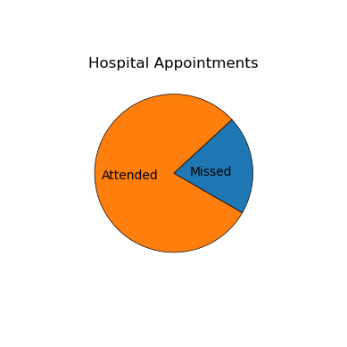

```python
y = np.array([show_counts['Yes'], show_counts['No']])
mylabels = ["Missed", "Attended"]
plt.pie(y, labels = mylabels, radius = 0.6, labeldistance = 0.2, startangle=330, wedgeprops = {"edgecolor" : "black", 'linewidth': .5})
plt.title("Hospital Appointments", x=.5, y=.8)
plt.show()
```

Next, I'll use the groupby function to get more details about which neighborhoods get the most missed appointments. Then, I'll calculate a ratio of missed-to-kept appointments by neighborhood to determine neighborhoods with the worst attendance rates.

```python
missed_count_by_neighbourhood = df[df['no_show'] == 'Yes'].groupby('Neighbourhood').Neighbourhood.count() #number of missed appointments in each neighborhood
kept_count_by_neighbourhood = df[df['no_show'] == 'No'].groupby('Neighbourhood').Neighbourhood.count() #number of kept appointments in each neighborhood
appt_proportions = missed_count_by_neighbourhood / kept_count_by_neighbourhood #ratio of missed-to-kept appointments by neighborhood
appt_proportions
```

```
Neighbourhood
AEROPORTO              0.142857
ANDORINHAS             0.299253
ANTÔNIO HONÓRIO        0.226244
ARIOVALDO FAVALESSA    0.281818
BARRO VERMELHO         0.274096
                         ...
SÃO JOSÉ               0.276307
SÃO PEDRO              0.266425
TABUAZEIRO             0.223916
UNIVERSITÁRIO          0.266667
VILA RUBIM             0.198592
Name: Neighbourhood, Length: 81, dtype: float64
```

Now, lets try plotting that on a line graph:

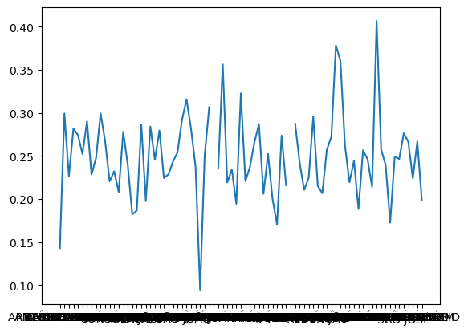

```python
plt.plot(appt_proportions.index, appt_proportions.values);
```

There are too many neighborhoods to be able to read those labels on the x-axis, but we can narrow down the real outliers in this dataset and take a closer look at them using this graph and the describe() function:

```python
appt_proportions.describe()
```

```
count    79.000000
mean      0.248762
std       0.049525
min       0.093750
25%       0.219923
50%       0.246243
75%       0.277093
max       0.406836
Name: Neighbourhood, dtype: float64
```

The graph seems to give more striking details. According to the graph, there are two neighborhoods with exceptionally high attendance (15% or fewer missed), and there are 3 or 4 neighborhoods with exceptionally low attendance (35% or more missed). Lets name those neighborhoods and then look more closely at them.

```python
appt_proportions[appt_proportions.values < .15] #neighborhoods with less than 15% no-shows
```

```
Neighbourhood
AEROPORTO      0.142857
ILHA DO BOI    0.093750
Name: Neighbourhood, dtype: float64
```

```python
appt_proportions[appt_proportions.values > .35] #neighborhoods with more than 35% no-shows
```

```
Neighbourhood
ITARARÉ          0.356233
SANTA CECÍLIA    0.378462
SANTA CLARA      0.360215
SANTOS DUMONT    0.406836
Name: Neighbourhood, dtype: float64
```

I have a hunch that the neighborhoods with exceptionally high attendance will also be very small. Let's see if that's true.

```python
df.query('Neighbourhood == "AEROPORTO"').PatientId.count()
```

```
8
```

```python
df.query('Neighbourhood == "ILHA DO BOI"').PatientId.count()
```

```
35
```

```python
df.query('Neighbourhood == "ITARARÉ"').PatientId.count()
```

```
3514
```

```python
df.query('Neighbourhood == "SANTA CECÍLIA"').PatientId.count()
```

```
448
```

```python
df.query('Neighbourhood == "SANTA CLARA"').PatientId.count()
```

```
506
```

```python
df.query('Neighbourhood == "SANTOS DUMONT"').PatientId.count()
```

```
1276
```

Yes, that seems to be the case. The two neighborhoods with much better attendance also have far fewer appointments scheduled.

#### Answer to Question 1:

My initial response to this information is that the areas with fewer appointments have higher attendance rates. This might be worth a follow-up; perhaps there is a correlation between the population of a neighborhood and attendance rates. However, my goal was only to find the hospitals at which attendance rates were the worst. At which hospitals are patients more likely to miss their appointments? The answer is: at the hospitals in ITARARÉ, SANTA CECÍLIA, SANTA CLARA, and SANTOS DUMONT. Other hospitals could be added to this list; any hospital with an attendance rate below the mean, but these four are the most poorly attended by proportion of appointments made.

### Research Question 2: Are any of the documented conditions (hypertension, diabetes, alcoholism, and handicap) more likely to result in a missed appointment?

We established a baseline ratio of missed to total appointments of ~.2 in Question 1. Does that mean hold true for patients with each of these conditions? Lets calculate the same ratio for each of these groups of patients.

Let's start with the rate of missed appointments for people with hypertension. I'm going to have to do this several times, so I'll define a custom function to find the ratio of missed appointments to total appointments given a condition:

```python
def get_ratio(dataframe, condition):
    temp_df = dataframe.loc[df[condition] == 1] #subset of patients with the specified condition
    condition_total = temp_df.no_show.count() #number of patients with that condition
    condition_missed = temp_df.loc[temp_df['no_show'] == "Yes"].no_show.count() # num. of those patients who missed
    condition_made = temp_df.loc[temp_df['no_show'] == "No"].no_show.count() #num. of patients who made (not used)
    return condition_missed/condition_total
```

```python
hyper_ratio = get_ratio(df, "Hypertension")
hyper_ratio
```

```
0.17301958625751113
```

That looks a bit lower than the overall mean. It looks like people with hypertension are more likely than normal to attend their appointments, although I can't say whether this difference is significant.

Now lets look at Diabetes:

```python
diabetes_ratio = get_ratio(df, "Diabetes")
diabetes_ratio
```

```
0.18003273322422259
```

Alcoholism?

```python
alcoholism_ratio = get_ratio(df, "Alcoholism")
alcoholism_ratio
```

```
0.20148809523809524
```

Handicaps?

```python
handicap_ratio = get_ratio(df, "Handicap")
handicap_ratio
```

```
0.18161535029004908
```

And what about people with none of those conditions? My function doesn't take multiple conditions, so I'll have to do this by hand:

```python
none_df = df.query('Handicap==0 & Alcoholism ==0 & Diabetes==0 & Hypertension==0')
none_df_total = none_df.count()
none_df_missed = none_df.query('no_show == "Yes"').no_show.count()
none_df_made = none_df.query('no_show == "No"').no_show.count()
none_ratio = none_df_missed/none_df_total
none_ratio.no_show
```

```
0.20927301908102003
```

Now lets compare those ratios using a bar graph

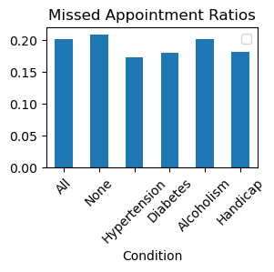

```python
condition_props = pd.DataFrame({'Condition':['All', 'None', 'Hypertension', 'Diabetes', 'Alcoholism', 'Handicap'],
                                'rate':[show_counts['Yes']/df.shape[0], none_ratio.no_show, hyper_ratio, diabetes_ratio, alcoholism_ratio,
                                        handicap_ratio]})
condition_props.plot.bar(x='Condition', y='rate', label = '_nolegend_', rot=45, figsize=(3,2));
plt.title('Missed Appointment Ratios')
plt.show()
```

#### Answer to Question 2:

The bar graph above shows there is some variation in attendance rates among people with different health conditions. However, having any of these conditions makes it less likely for a patient to miss an appointment. Without more sophisticated statistical analysis, I can't say whether any of this variation is significant or not. It does seem very minimal; something around 3 percentage points at the most.

### Research Question 3: Are patients more likely to miss appointments if they schedule too far in advance?

Let me just start out by exploring the data. Let's look some more at how long in advance people schedule their appointments.

```python
lead_time = (df.AppointmentDay - df.ScheduledDay) / np.timedelta64(1, 'D') #Calculate lead times
lead_time.describe().astype(int)
```

```
count    110527
mean          9
std          15
min          -6
25%           0
50%           3
75%          14
max         178
dtype: int32
```

The average lead time is 9 days.

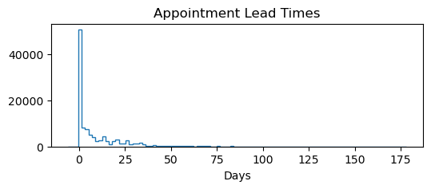

```python
lead_time_in_days = lead_time.astype(int)
lead_time_in_days.hist(bins=100, histtype='step', figsize=(6,2))
plt.title('Appointment Lead Times')
plt.grid(visible=None)
plt.xlabel('Days')
plt.show()
```

This data will need additional cleaning. People are scheduling their appointments up to negative six days in advance, i.e. appointments are being added to the schedule retroactively. Lets start by adding the 'lead_time_in_days' series as a new column to the original and then remove rows where that column is negative.

```python
df['lead_time'] = lead_time_in_days.values
df.query('lead_time > 0').lead_time.describe()
```

```
count    66746.000000
mean        15.785590
std         16.590956
min          1.000000
25%          4.000000
50%         11.000000
75%         23.000000
max        178.000000
Name: lead_time, dtype: float64
```

Now lets compare histograms of lead times when people miss their appointments vs when they make their appointments

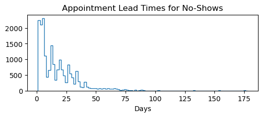

```python
df.query('lead_time > 0 & no_show == "Yes"').lead_time.hist(bins=100, histtype='step', figsize=(6,2))
plt.title('Appointment Lead Times for No-Shows')
plt.grid(visible=None)
plt.xlabel('Days')
plt.show()
```

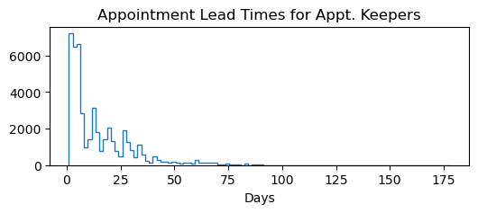

```python
df.query('lead_time > 0 & no_show == "No"').lead_time.hist(bins=100, histtype='step', figsize=(6,2))
plt.title('Appointment Lead Times for Appt. Keepers')
plt.grid(visible=None)
plt.xlabel('Days')
plt.show()
```

Those histograms look very similar. Maybe we'll be able to see a difference when we look at the numbers.

```python
df.query('lead_time > 0 & no_show == "Yes"').lead_time.describe() #Lead-times for no-shows
```

```
count    19409.000000
mean        17.148282
std         16.610089
min          1.000000
25%          5.000000
50%         13.000000
75%         25.000000
max        178.000000
Name: lead_time, dtype: float64
```

```python
df.query('lead_time > 0 & no_show == "No"').lead_time.describe() #Lead-times for appointment keepers
```

```
count    47337.000000
mean        15.226863
std         16.550879
min          1.000000
25%          4.000000
50%          9.000000
75%         22.000000
max        178.000000
Name: lead_time, dtype: float64
```

#### Answer to Question 3:

It looks like the mean lead time is two days less when people make their appointments than it is when people miss their appointments. Like the last question, the difference here is very small, and I can't say whether it's significant without using more sophisticated statistical tools, but initially it looks like people are a little more likely to keep their appointment if they are scheduled a couple of days sooner.

### Research Question 4: How effective are SMS reminders at reducing missed appointments?

I will start out with an initial caveat: the data source does not say that the SMS messages sent were appointment reminders; only that the patients received at least one SMS message. Given that caveat, this question will explore whether receiving an SMS message acted as a reminder and increased a patient's likelihood to attend the appointment. I'll start out by looking at ratios of attendance.

```python
df.groupby('SMS_received').no_show.value_counts(normalize=True).filter(like='No', axis=0)
```

```
SMS_received  no_show
0             No         0.832967
1             No         0.724255
Name: proportion, dtype: float64
```

It looks like the rate of attendance actually decreases from 83% to 72% when people receive an SMS message. Let's get a visual representation of that change:

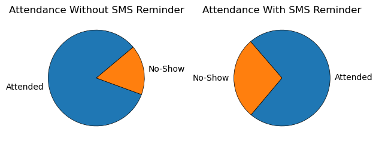

```python
#Data:
no_sms = df.groupby('SMS_received').no_show.value_counts(normalize=True).filter(like='0', axis=0).values
yes_sms = df.groupby('SMS_received').no_show.value_counts(normalize=True).filter(like='1', axis=0).values

#First subplot - SMS messages not received
plt.subplot(1, 2, 1)
mylabels = ["Attended", "No-Show"]
plt.pie(no_sms, labels = mylabels, startangle=40, wedgeprops = {"edgecolor" : "black", 'linewidth': .5});
plt.title("Attendance Without SMS Reminder")

#Second subplot - SMS messages received
plt.subplot(1, 2, 2)
plt.pie(yes_sms, labels = mylabels, startangle=230, wedgeprops = {"edgecolor" : "black", 'linewidth': .5});
plt.title("Attendance With SMS Reminder")

plt.tight_layout()
plt.show()
```

#### Answer to Question 4:

The answer appears to be that those who received an SMS message are less likely to attend their appointment than those who did not receive an SMS message. The difference is also rather wide, although I can't say with any mathematical confidence that it's significant. This a surprising result; I expected the opposite. There may be additional information that could make this make sense; maybe SMS messages are only sent to people with a history of missing their appointments. Without more information, I can't say.

## Conclusions

**Question 1:** At which hospitals are patients most likely to miss their appointment? Answer: at ITARARÉ, SANTA CECÍLIA, SANTA CLARA, and SANTOS DUMONT. Other hospitals have attendance rates that are much closer to the mean.  
**Question 2:** Are any of the documented conditions (hypertension, diabetes, alcoholism, and handicap) more likely to result in a missed appointment? No; each of these conditions, individually, is actually likely to increase attendance. This is a surprising result because I would these conditions to cluster above and below the mean attendance ratio; instead they all have a lower ratio of missed-to-total appointments scheduled. Additional research might focus on whether a combination of more than one condition will decrease the attendance rate.  
**Question 3:** Are patients more likely to miss appointments if they schedule too far in advance? No, not really. Those who miss their appointments and those who make their appointments have roughly the same distribution in appointment lead times. There is a difference in a couple of days, but I can't say whether that is significant, or whether it's practical to ask people to schedule an appointment two days earlier.  
**Question 4:** How effective are SMS reminders at reducing missed appointments? They seem to be counterproductive, if their intent is to remind people to attend their appointment. Additional information is needed to explain this result, including why people are sent SMS messages, and the demographics of those who receive them.

### Limitation

None of these results have been tested for statistical significance; they are exploratory in nature. Results should not be used to determine whether an individual patient is likely to attend an appointment. In addition, none of these results imply causality; I have not concluded that having a medical condition or receiving no SMS communication is likely to increase a patient's likelyhood of attending an appointment.

### Resources

N/A

```python
from subprocess import call
call(['python', '-m', 'nbconvert', 'Investigate_a_Dataset.ipynb'])
```

```
1
```